# Introduction/How To Use This Notebook

## numpy's where() command (like MATLAB's find() command)

The `where()` function allows to to locate an element in an array that satisfies a condition. Use "help(np.where)" to see all of the possible inputs to this function and how to use them. As a quick example, suppose you have the function:

$$y = 1-e^{-t}$$

and you'd like to know at what time this function is first greater than or equal to 0.632. This could be accomplished using the following code:

```
found index was 100
```

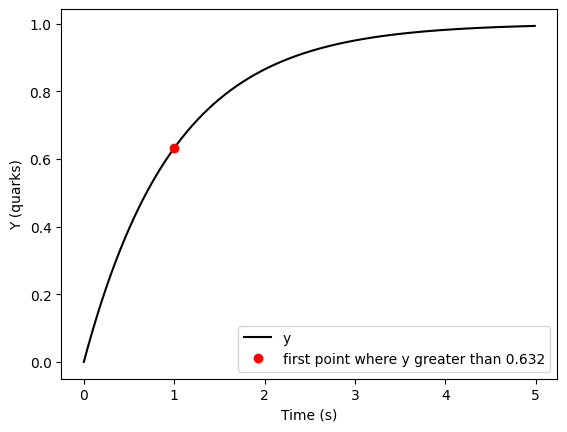

```python
import matplotlib.pyplot as plt
import numpy as np

#set up variable to hold time values
t = np.arange(0,5,.01)
#implement my equation:
y = 1 - exp(-t);
#use where() to locate which VALUE in my array y is greater than .632.
my_index = np.where(y>0.632)[0][0] #tells the find() command to find one index in the array y
#(the first one) for which y is greater than 0.632.
#this index will be an integer between 1 and the length of y, allowing me to use it to "index" the variable
#and find the values I'm interested in
print("found index was "+str(my_index))
#now, to use this, I would like to see which y value that is, and at what time it occurs:
my_y = y[my_index]
my_time = t[my_index]

#just to make this visual, let's plot y vs. t, and also plot our "found" value on top.
plt.figure()
plt.plot(t,y,'k',my_time,my_y,'ro')
plt.xlabel('Time (s)')
plt.ylabel('Y (quarks)')
plt.legend(['y','first point where y greater than 0.632'])
```

## numpy.polyfit()

Python's numpy library can be used to estimate a "best fit" polynomial function to match a dataset. The term "best fit," in this context, means that the sum of the squared error between the model and the data is minimized. The command used to produce the set of coefficients is "polyfit." An example of how to use the "polyfit" command to produce the best-fit line for a dataset is shown below.

```
estimated m: -3.0277218311642553, estimated b: 4.17567672896315
```

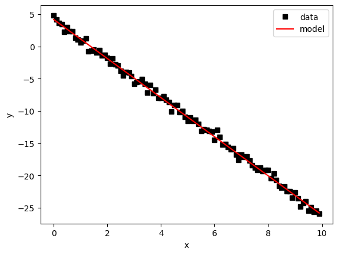

```python
# first, create some fake "data" we will fit a line to, in order to see how "polyfit" works.
xfakedata = np.arange(0,10,.1);
yfakedata = -3*xfakedata + 4 + .5*np.random.randn((xfakedata.size)); #the randn() on the end produces some random "noise" on our fake data.
#this simulates the effect of having error in our measurements. If polyfit does its job, we should get the line y = -3x+4 back!

#now we will actually use polyfit. The array "coefficients" will contain [m b] in the equation y = m*x+b.
#the second argument to the polyfit() function is the ORDER of the polynomial. A line is a polynomial of order 1.
#for reference, a quadratic is a polynomial of order 2.
coefficients = np.polyfit(xfakedata,yfakedata,1);
#was m=-3 and b=4?
m_estimate = coefficients[0]
b_estimate = coefficients[1]

print("estimated m: "+str(m_estimate)+", estimated b: "+str(b_estimate))

#now, these coefficients fully define a "model" of our relationship y = m*x+b. Let's produce predictions based on this model
ymodel = m_estimate*xfakedata + b_estimate;

#now plot the data and the model together to evaluate.
plt.figure()
plt.plot(xfakedata,yfakedata,'ks',xfakedata,ymodel,'r')
plt.xlabel('x')
plt.ylabel('y')
plt.legend(['data','model'])
```

# Classes in Python

Python is an object-oriented language. This means that it has the ability to define "classes" that define "objects." In programming, an object is a data structure that has both members (variables that are scoped to "belong" to the object) and methods (functions that the object can perform). A robot, for example, is a good candidate to talk about what an "object" is. A robot has properties like color, size, number of wheels... these belong to each individual robot and may be different from robot to robot, but we could come up with a pretty good list of things we'd need to know about a robot in order to define it as such. A robot also can *do* things... it has methods like "go forward" or "grab the ball."

Programming a class is about conceptualizing what you want to do in terms of "objects." A very brief but good introduction to Python objects is given at [this link](https://towardsdatascience.com/introduction-to-python-classes-da526ff745df).

# Common Errors